# Introdução ao Python

*Prof. Tito Dias Júnior*

### **A linguagem**

Python é uma linguagem bastante versátil e interpretada, isto é, não é necessário compilar para executar o programa. Isso é muito conveniente para aprender a programar, uma vez que podemos executar partes do código enquanto programamos. Normalmente, a elaboração do programa é realizada digitando-se o código em um IDE (*Integrated Development Environment*) ou Ambiente de Desenvolvimento Integrado, onde podemos digitar e executar o programa de forma integrada com o interpretador da linguagem.

### **Instalando**

Para efetuar a instalação do Python, pode-se acessar diretamente o site oficial [Python](https://www.python.org), ou instalar o pacote fornecido pela [Anaconda](https://get.anaconda.com/build-vs-buy/) que traz outros aplicativos úteis, incluindo o Spyder, uma IDE bastante utilizada para programação.

Nesse curso, utilizaremos o Jupyter Notebook que é um arquivo que combina células de texto (*markdown*) e de código (*code*) no mesmo arquivo. Para executar os notebooks disponíveis nesse curso basta copiar o endereço da pasta que contém o notebook no campo "GitHub repository name or URL" no site [mybinder.org](https://mybinder.or), aguardar enquanto ele gera um ambiente de trabalho e começar a executar as células. Todas as alterações realizadas no notebook serão perdidas após sair do ambiente do binder.

## Fundamentos

### Variáveis

Representa um espaço de memória utilizado para armazenar valores utilizados. Quando se aloca um espaço na memória deve-se especificar o tipo de variável, por exemplo, valor númerico inteiro, fracionários, vetores, etc. e após definida a variável pode receber valores diferentes mas não tipos diferentes.

```python
# A linha que começa com o símbolo de hashtag é interpretada como um comentário e não é executada.
# Em um programa, é muito importante utilizar os comentários para registrar o que se realiza ou pensa durante a programação,
# para que você possa se comunicar com outros programadores ou consigo no futuro
a = 1               # Variável numérica inteira (int)
print('a = ', a)    # Função print, utilizada para mostrar texto e valores no terminal de execução.
b = 2.1*1           # Variável numérica de ponto flutuante (float)
print('b = ', b)
```

```
a =  1
b =  2.1
```

### Strings

*Strings* são sequências de caracteres, também conhecidas como cadeias de caracteres ou vetores de caracteres. Elas podem ser "somadas" ou concatenadas com outras strings e podem ser segmentadas com o uso de "[:]", como mostrado no exemplo:

```python
string1 = 'Este é um programa em Python'         # Define uma variável tipo string
string2 = 'para calcular a inversa da Matriz A'  # Observe que as letras ficam entre as aspas simples
print('Strings concatenadas:', string1 + ' ' + string2)                   # Mostra as strings concatenadas com o espaço ' '
print('Segmento final da string: ', string1[22:28])
```

```
Strings concatenadas: Este é um programa em Python para calcular a inversa da Matriz A
Segmento final da string:  Python
```

As strings são variáveis "imutáveis", ou seja, uma vez definida não admitem que sejam alteradas, veja o exemplo abaixo que tenta modificar a primeira letra da *string1* e que, quando executado, gera um erro:

```python
string1[0] = 'e'
```

```
---------------------------------------------------------------------------
TypeError                                 Traceback (most recent call last)
<ipython-input-4-ab5f24367b27> in <module>
----> 1 string1[0] = 'e'

TypeError: 'str' object does not support item assignment
```

### *Tuples*

```python
tp = ('José','Alves', (12, 4, 2006)) # Define a tupla para guardar nome, sobrenome e data
nome, sobrenome, data = tp           # Atribui cada objeto da tupla a uma variável
print('Nome: ', nome)                # Mostra a variável nome
ano = data[2]                        # Atribui o terceiro elemento (ano) da data à variável ano.
print('Ano: ', ano)
nome_completo = tp[0] +' '+ tp[1]
print('Nome Completo: ', nome_completo)
```

```
Nome:  José
Ano:  2006
Nome Completo:  José Alves
```

### *Listas*

As listas são semelhantes às tuplas com a diferença de que seus valores e tamanho podem ser alterados. Vejam os exemplos a seguir

```python
a = [1.0, 2.0, 3.0]    # Cria uma lista
a.append(4.0)          # Acrescenta um elemento na lista
print(a)
a.insert(0,1.1)        # Insere um elemento na posição 0
print(a)
print(len(a))          # Mostra o número de elementos (tamanho) da lista
a[2:5] = [0.0, 0.0, 0.0]    # Modifica os elementos 2, 3 e 4
print(a)
```

```
[1.0, 2.0, 3.0, 4.0]
[1.1, 1.0, 2.0, 3.0, 4.0]
5
[1.1, 1.0, 0.0, 0.0, 0.0]
```

É importante destacar que se fazemos $b = a$ não estamos criando um nova lista $b$, mas uma nova forma de se referir aos valores de $a$, ou seja, qualquer alteração em $a$ também será observada em $b$. Assim, para criarmos um cópia de $a$ é necessário fazer $b = a[:]$.

Podemos ainda representar matrizes como listas de listas, posteriormente, veremos uma forma matematicamente mais adequada para trabalhar com matrizes. Por equanto, vejamos matrizes como listas de duas dimensões, sendo a primeira linhas e a segunda colunas

```python
A = [[1, 2, 3], \
[4, 5, 6], \
[7, 8, 9]]            # A barra invertida é um símbolo de continuação de linha
print(A)
print(A[1][:]) # Mostrando a segunda linha. Observe que a numeração de elementos iniciam sempre em zero
print(A[1][1]) # Mostrando elemento da segunda linha e segunda coluna
```

```
[[1, 2, 3], [4, 5, 6], [7, 8, 9]]
[4, 5, 6]
5
```

### *Operadores aritméticos*

Como em uma calculadora, para executar operações matemáticas neccessitamos de operadores aritméticos. No Python, eles são:

- $a+b$ -> Adição
- $a-b$ -> Subtração
- $a/b$ -> Divisão
- $a*b$ -> Multiplicação
- $a$**$b$ -> Exponenciação
- $a$%$b$ -> Divisão modular: Mostra o resto da divisão

### *Operadores relacionais*

Para efetuar comparações entre valores, precisamos do operadores relacionais. No Python, eles são:

- $<$ -> Menor que
- $>$ -> Maior que
- $<=$ -> Menor ou igual a
- $>=$ -> Maior ou igual a
- $==$ -> Igual a
- $!=$ -> Diferente de

## *Condicionais*

### if

Para construimos um programa, frequentemente nos deparamos com situações em que precisamos tomar uma decisão de acordo com valores de varíaveis calculadas no decorrer da execução. A seguir veremos o condicional *if*, que testa uma condição e se ela for verdadeira ele executa o bloco de comandos indentados a seguir, por exemplo

```python
a = 1
if a == 1:    # Verifica se a é igual a 1
    print("Condição verdadeira")  # Bloco a ser executado, observe que ele está recuado (indentado) em relação ao if
```

```
Condição verdadeira
```

### else

Existe complementos ao comando *if*, por exemplo o comando *else* que vem logo abaixo do bloco a ser executado caso a condição seja verdadeira, estabelece o bloco de comando para o caso da condição não ser verdadeira, por exemplo

```python
b = 2
if b == a:
    print("Condição verdadeira")
else:
    print("Condição falsa")
```

```
Condição falsa
```

Existe ainda outro comando, o *elif* que é executado caso a condição do *if* seja falsa e a sua seja verdadeira, veja o exemplo

```python
b = 3
if b == a:
    print("são iguais")
elif b>a:
    print(b,"é maior que", a)
else:
    print(print(b,"é menor que", a))
```

```
3 é maior que 1
```

## *Loops*

Os loops são utilizados para realizar cálculos repetitivos ou *iterativos* até que determinadas condições são satisfeitas. Os mais utilizados são o loop *while* e o *for*.

### *while*

O *while* executa um bloco de comandos indetados se a enquanto a condição estabelecida seja verdadeira, ou seja, após cada execução do bloco de comandos, antes de se iniciar novamente a execução, a condição é novamente avaliada, e se verdadeira, repete-se novamente o ciclo até que a condição se torne falsa, veja o exemplo:

```python
a_min = 0.3
a_lista = [] # Cria uma lista vazia
n = 1
while a > a_min:
    a = 1.0/n
    a_lista.append(a) # Adiciona um elemento à lista
    n = n + 1
print(a_lista)
```

```
[1.0, 0.5, 0.3333333333333333, 0.25]
```

### *for*

O *for* executa um bloco de comandos indetados por um número conhecido de vezes, veja o exemplo:

```python
nMax = 5
a_lista = []
for n in range(1,nMax): # executa o for para n vairando de 1 a nMax
    a_lista.append(1.0/n)
print(a_lista)
```

```
[1.0, 0.5, 0.3333333333333333, 0.25]
```

Os comandos *while* e *for* admitem também o uso do comando *else*, para quando se deseja executar alguma instrução em caso de não atendimento da condição estabelecida; do comando *break* quando se deseja interromper a execução do loop.

```python
list = ['Tiago','Ivan','Henrique', 'Paulo', 'João']
nome = input('Digite um nome: ') # Caixa de texto (prompt) de entrada de dados
print(nome)
for i in range(len(list)): # Len(list) determina o número de elementos da lista
    if list[i] == nome:
        print(nome,'é o número',i + 1,'na lista')
        break
else:
    print(nome,'não está na lista')
```

```
 não está na lista
```

## Conversão de Tipos de Variáveis

- int(x) -> Converte x para inteiro
- float(x) -> Converte x para float
- complex(a) -> Converte x para um número complexo na forma x + 0j, onde j é o número imaginário $j = \sqrt{-1}$
- complex(x,y) -> Converte o par (x,y) para complexo na forma x + yj

## Funções Matemáticas

- abs(a) -> Valor absoluto ou módulo de a
- max(sequence) -> Maior elemento da sequência
- min(sequence) -> Menor elemento da sequência
- round(a,n) -> Arredonda para n casas decimais
- cmp(a,b) -> retorna $\bigg\{\begin{smallmatrix} −1 if a < b\\ 0 if a = b\\ 1 if a > b \end{smallmatrix}$

## *Input*

Para solicitar que o usuário do programa forneça algum valor podemos utilizar a função *input* e a função *eval* quando desejamos converter o valor entrado no *input* de *string* para valor numérico.

```python
a = input('Digite a:' )
print(a, type(a)) # Mostra a e o tipo da variável
b = eval(a)       # Converte a para um número
print(b,type(b))
```

```
1 <class 'str'>
1 <class 'int'>
```

## *Print*

As varáveis podem ser mostradas no terminal com o uso da função *print(var1,var2,...)*, para a impressão essa função converte todas as variáveis para *string* e as mostra separadas por espaços. Há caracteres especiais que podem ser usados com a função *print*, por exemplo, '\n' que muda de linha.

```python
a = 1234.56789
b = [2, 4, 6, 8]
print('a =',a, '\nb =',b)  # Mostra as variáveis mudando de linha
```

```
a = 1234.56789
b = [2, 4, 6, 8]
```

Essa função permite também a utilização de regras de formatação numérica para representação de números inteiros ou reais.

`'{:fmt1}{:fmt2}...'.format(var1,var2,...)`

As formatações podem ser especificadas utilizando a nomenclatura abaixo, onde $w$ é o número de casas do campo formatado e $d$ é o número de casas decimais, e $e$ é utilizado para representação em notação exponencial:

- wd Integer
- w.df Floating point notation
- w.de Exponential notation

No exemplo abaixo, são mostrados números formatados:

```python
a = 1234.56789
n = 5555
print('{:7.2f}'.format(a))
print('n = {:6d} completando com espaços'.format(n))
print('n = {:06d} inteiro com seis casas, completando com zeros'.format(n))
print('Em notação decimal: {:12.4e} e inteiro com seis casas decimais {:6d}'.format(a,n))
```

```
1234.57
n =   5555 completando com espaços
n = 005555 inteiro com seis casas, completando com zeros
Em notação decimal:   1.2346e+03 e inteiro com seis casas decimais   5555
```

## Abrindo e Fechando Arquivos

Antes de acessar um arquivo armazenado, é necessáario criar um objeto de arquivo (file object):

file_object = open(nome_arquivo, ação)

Aqui você cria o objeto de arquivo com nome igual a nome_arquivo, por ex. 'dados.txt' e define qual ação você operará no arquivo. As ações podem ser:

- ’r’ Ler um arquivo existente.
- ’w’ Escrever em um arquivo. Se ele já não existir, ele é criado.
- ’a’ Acrescentar no fim de um arquivo.
- ’r+’ Ler e Escrever de um arquivo existente.
- ’w+’ Mesmo que ’r+’, mas o arquivo é criado se ele não existir.
- ’a+’ Mesmo que ’w+’, mas os dados são acrescentados no final do arquivo.

Quando você terminar de manipular o arquivo, deve-se fechá-lo com

file_object.close()

### Lendo dados de um arquivo aberto

variavel_string = file_object.read(n) -> Lê n caracteres de um arquivo e retorna na forma de string variavel_string = file_object.read() -> Lê todos os caracteres de um arquivo. variavel_string = file_object.readline(n) -> Lê n caracteres da linha atual. variavel_string = file object.readlines() -> Lê todas as linhas de um arquivo

Um outra forma de ler os dados de um arquivo pode ser vista no exemplo abaixo. O arquivo a ser lido é "dados.txt' que contém dados de intensidade solar no formato (ano mês dia intensidade):

1896 05 26 40.94  
1896 05 27 40.58  
1896 05 28 40.20

O exemplo a seguir deve criar uma lista x que contenha somente os dados de intensidade solar.

```python
x = []
data = open('files\dados.txt','r')  # Abre o arquivo para leitura
for line in data:                   # Define um loop para ler todas as linhas no objeto data
    x.append(eval(line.split()[3])) # Lê a linha, extrai o elemento da 4ª coluna e transforma em real (eval)
data.close()                        # Fecha o arquivo
print(x)                            # Mostra o vetor x
```

```
[40.94, 40.58, 40.2]
```

## Escrevendo dados em um arquivo

No próximo exemplo, veremos como gravar dados em um arquivo:

```python
f = open('files/testfile.txt','w')               # Cria e abre o arquivo testfile
for k in range(101,111):                     # Define um loop com k variando de 101 a 111
    f.write('{:4d} {:6d}'.format(k,k**2))    # Escreve no objeto f os valores k e k*k no arquivo
    f.write('\n')                            # Acrescenta uma nova linha
f.close()
```

Abrindo o arquivo testefile.txt no bloco de notas, obtemos:

101 10201  
102 10404  
103 10609  
104 10816  
105 11025  
106 11236  
107 11449  
108 11664  
109 11881  
110 12100

A função 'print' também pode ser utilizada para se escrever em um arquivo redirecionado sua saída para o objeto de arquivo:

`print(variavel1, variavel2, . . . ,file = file_object)`

Assim, pode-se utilizar normalmente a função print.

## Controle de Erros

Quando um erro ocorre em um programa em execução, uma mensagem de exceção é gerada e o programa é interrompido. As exceções podem ser capturadas e tratadas de forma adequada com os comandos `try` e `except`. Por exemplo, se tentamos dividir por zero, o programa gera uma exceção de `ZeroDivisionError` que pode ser capturada e tratada como no exemplo a seguir:

```python
z = 15.0/0.0
```

```
---------------------------------------------------------------------------
ZeroDivisionError                         Traceback (most recent call last)
<ipython-input-34-3c30fdf190ff> in <module>
----> 1 z = 15.0/0.0

ZeroDivisionError: float division by zero
```

```python
try:                           # Testa a operação que pode causar erro
    c = 12.0/0.0
except ZeroDivisionError:      # Captura a exceção devido à divisão por zero
    print('Não foi possível executar a operação: Divisão por zero' ) # Dá um aviso ou uma solução para o erro
```

```
Não foi possível executar a operação: Divisão por zero
```

## Funções e Módulos

Uma função é uma parte do programa que pode ser executada várias vezes para retornar um valor. Por exemplo, a função seno retorna o valor do seno de um ângulo fornecido, também chamado de argumento da função.

Para definir uma função, utilizamos o comando `def`:

```
def func_name(param1, param2,. . .):
    Operações executadas
    return valor_retornado
```

O exemplo a seguir define uma função que pode ser usada para defivar numericamente outra função em um ponto x:

```python
# Função que deriva uma função fornecida por diferenças finitas
def derivadas(f,x,h=0.0001):          # Define a função derivadas e h tem um valor default ou padrão
    df =(f(x+h) - f(x-h))/(2.0*h)          # Derivada primeira
    ddf =(f(x+h) - 2.0*f(x) + f(x-h))/h**2 # Derivada segunda
    return df,ddf                          # Retorna os valores das derivadas em x
```

Podemos, por exemplo, usar a função derivadas para nos retornar as derivadas da função seno no ponto $x=\pi/2$

```python
from math import sin             # Importa a função seno do módulo math
df,ddf = derivadas(sin,3.1415/2) # Retorna as derivadas calculadas utilizando o valor defaul para h
print('First derivative =',df)   # Mostra a primeira derivada
print('Second derivative =',ddf) # Mostra a segunda derivada
```

```
First derivative = 4.632679462268641e-05
Second derivative = -0.999999993922529
```

O número de argumentos de uma função pode ser deixado livre, por exemplo:

```
def func(x1,x2,*x3)
```

Nesse caso, os dois primeiros argumentos são posicionais e o terceiro é uma tupla e pode conter quantos elementos forem passados como argumentos para a função, por exemplo:

```
func(a,b,c,d,e)
```

```python
def squares(a):
    for i in range(len(a)): # Define o loop onde i varia até o tamanho da lista
        a[i] = a[i]**2

a = [1, 2, 3, 4] # Lista com 4 elementos
squares(a)
print(a) # ’a’ agora contém ’a**2’

b = [1, 2, 3, 4, 5] # Lista com 5 elementos
squares(b)
print(b) # ’b’ agora contém ’b**2’
```

```
[1, 4, 9, 16]
[1, 4, 9, 16, 25]
```

### Comando Lambda

Se uma função tem a forma de uma expressão matemática, ela pode ser definida de forma simplificada com o comando $lambda$ `func name = lambda param1, param2,...: expression`, por exemplo:

```python
hipotenusa = lambda x,y : x**2 + y**2
print(hipotenusa(3,4))
```

```
25
```

## Módulos

A ideia de se criar funções vem da necessidade de se reutilizar o código várias vezes, como a funnção cosseno por exemplo. Nesse mesmo sentido, poderíamos pensar em agrupar determinadas funções que tem algum em comum e sempre que necessário utilizá-las em nossos programas computacionais. Esse agrupamento denominamos Módulos (*module*) em Pynthon, e quando queremos usar as funções agrupadas podemos importar o módulo de interesse:

`from module_name import *`

O Python possui incontáveis módulos que contém funções ou métodos para as mais diversas tarefas. Podemos ainda, conforme a necessidade e conveniência, modificiar módulos existentes ou criar nossos próprios módulos. A seguir veremos alguns módulos úteis para a disciplina de Métodos Numéricos.

## Módulo Matemáticos

### Módulo `math`

Muitas funções matemáticas são incluídas nesse módulo. O seguinte comando importa todas as funções do módulo *math*.

```
from math import *
```

Se quisermos importar apenas uma ou mais funções específicas basta relacioná-las após o comando *import*.

```python
from math import sin, cos, tan
print('tg(0.5) = ',sin(0.5)/cos(0.5))
print('tg(0.5) = ', tan(0.5))
```

```
tg(0.5) =  0.5463024898437905
tg(0.5) =  0.5463024898437905
```

Você pode ainda importar o módulo atribuindo um "apelido", como mostrado a seguir:

```python
import math as m
print('tg(0.5) = ',m.sin(0.5)/m.cos(0.5))
print('tg(0.5) = ', m.tan(0.5))
```

```
tg(0.5) =  0.5463024898437905
tg(0.5) =  0.5463024898437905
```

Para saber quais funções estão agrupadas em um módulo, você pode usar o comando *dir(modulo)*, por exemplo, *dir(math)* listará todas as funções agrupadas nesse módulo. Para aprender mais sobre os módulos e suas funções você pode procurar ajuda no Google.

## Outros Módulos úteis

### cmath

Muitas das funções presentes em *math* para serem utilizadas com números complexos.

### numpy

A lista completa de funções agrupadas em *numpy* é muito extensa e pode ser consultada em www.numpy.org . À medida que progredirmos no curso, aprenderemos as funções necessárias.

### Criando *Arrays*

Para criar um *array* usamos:

```
nome = array(list,tipo)
```

Podemos ainda criar tipos específicos de *arrays*:

```
array_de_zeros = zeros((dim1,dim2),tipo)
array_de_uns = ones((dim1,dim2),tipo)
array_em_intervalo = arange(inicio,fim,incremento)
```

Veja os exemplos:

```python
from numpy import *
a = array([[2.0, -1.0],[-1.0, 3.0]])        # Cria um array 2x2, o equivalente a uma matriz
print('a = ',a)                             # Veja a função print mostra o array como em forma de matriz

print('Matriz 2x2 de uns\n',ones((2,2)))    #Cria e mostra uma matriz 2x2 com elementos iguais a 1.
print('Vetor de zeros inteiros\n ',zeros(3), int)       #Cria e mostra um array com três elementos iguais a zeros inteiros ou um vetor de zeros.
print('vetor intervalo \n',arange(2,10,2))  #Cria e mostra um array que começa em 2, termina em 10, variando de 2 em 2.
```

```
a =  [[ 2. -1.]
 [-1.  3.]]
Matriz 2x2 de uns
 [[1. 1.]
 [1. 1.]]
Vetor de zeros inteiros
  [0. 0. 0.] <class 'int'>
vetor intervalo
 [2 4 6 8]
```

### Acesso a elementos do *array*

Para um *array* bidimensional, matriz 2x2, podemos acessar o valor de um dos elementos a[i,j], onde i é linha e j é a coluna onde se encontra o elemento.

$\begin{pmatrix} a_{11} & a_{12} \\ a_{21} & a_{22}\end{pmatrix}$

E para acessar um elemento escolhido basta então especificar os índices i e j, como no exemplo a seguir:

```python
from numpy import *
A = ones((3,3),int)
print(A)
A[0] = [0,0,0] # Muda os valores da primeira linha
A[1,1] = 2 # Muda o elemento que está na segunda coluna e segunda linha
A[2,0:2] = [3,3] # Muda as duas primeiras colunas da terceira linha
print(A)
```

```
[[1 1 1]
 [1 1 1]
 [1 1 1]]
[[0 0 0]
 [1 2 1]
 [3 3 1]]
```

### Operações com *array*

Assim como vetores e matrizes podemos realizar algumas operações matemáticas:

```python
from numpy import * # Funções importadas do módulo numpy podem ser aplicadas diremente sobre um array
v = array([0.0, 4.0, 9.0, 16.0])
print('Divisão de vetor por um escalar\n', v/16.0)
print('Subtração de um escalar\n', v - 4.0)
print('Aplicação da função raiz quadradda em cada elemento do vetor\n', sqrt(v))
```

[output not shown]

### Funções *array*

Há ainda algumas funções que realizam operações sobre os *arrays* sendo bastante úteis para operações normalmente utilizadas em álgebra linear.

```python
from numpy import *
A = array([[4,-2,1],[-2,4,-2],[1,-2,3]],float) # Define uma matriz 3x3
print('A=',A)
b = array([1,4,3],float)                       # Define um vetor 1x3
print('b =',b)
print('Diagonal principal da matriz A', diagonal(A)) # Mostra diagonal principal da matriz A
print('Primeira subdiagonal', diagonal(A,1)) # Mostra primeira subdiagonal
print('Mostra o traço',trace(A)) # Mostra o traço: Soma dos elementos da diagonal principal
print('Índice do maior elemento',argmax(b)) # Índice do maior elemento do vetor
print('Índices dos menores elementos de coluna',argmin(A,axis=0)) # Índices dos menores elementos de coluna
print('Matriz identidade\n',identity(3)) # Matriz identidade
```

[output not shown]

## Produtos de *arrays*

Há ainda as funções cálculo de produtos entre *arrays*, tal como em álgebra vetorial, temos o produto interno, produto externo e produto escalar.

```python
from numpy import *
x = array([7,3])
y = array([2,1])
A = array([[1,2],[3,2]])
B = array([[1,1],[2,2]])
# Produto escalar
print("dot(x,y) =\n",dot(x,y)) # {x}.{y}
print("dot(A,x) =\n",dot(A,x)) # [A]{x}
print("dot(A,B) =\n",dot(A,B)) # [A][B]
# Produto interno
print("inner(x,y) =\n",inner(x,y)) # {x}.{y}
print("inner(A,x) =\n",inner(A,x)) # [A]{x}
print("inner(A,B) =\n",inner(A,B)) # [A][B_transposta]
# Produto externo
print("outer(x,y) =\n",outer(x,y))
print("outer(A,x) =\n",outer(A,x))
print("outer(A,B) =\n",outer(A,B))
```

```
dot(x,y) =
 17
dot(A,x) =
 [13 27]
dot(A,B) =
 [[5 5]
 [7 7]]
inner(x,y) =
 17
inner(A,x) =
 [13 27]
inner(A,B) =
 [[ 3  6]
 [ 5 10]]
outer(x,y) =
 [[14  7]
 [ 6  3]]
outer(A,x) =
 [[ 7  3]
 [14  6]
 [21  9]
 [14  6]]
outer(A,B) =
 [[1 1 2 2]
 [2 2 4 4]
 [3 3 6 6]
 [2 2 4 4]]
```

### Módulo de álgebra linear

O módulo *numpy* tem ainda um módulo de álgebra linear *linalg* que contém rotinas prontas para inversão de matrizes e solução de sistemas lineares Por exemplo:

```python
from numpy import array
from numpy.linalg import inv,solve
A = array([[ 4.0, -2.0, 1.0], \
[-2.0, 4.0, -2.0], \
[ 1.0, -2.0, 3.0]])
b = array([1.0, 4.0, 2.0])
print(inv(A)) # Inversa da matriz A
print(solve(A,b)) # Resolve o sistema [A]{x} = {b}
```

```
[[0.33333333 0.16666667 0.        ]
 [0.16666667 0.45833333 0.25      ]
 [0.         0.25       0.5       ]]
[1.  2.5 2. ]
```

Para criar uma cópia de uma matriz basta escrever B = A.copy()

### Vetorizando algoritmos

Algumas vezes as propriedades inerentes às funções do módulo *mumpy* podem ser utilizadas para substituir o uso de loops *for* ou *while*, conhecido como processo de vetorização. Por exemplo, a expressão:

$ s=\sum_{i=0}^{100} \sqrt{\frac{i\pi}{100}}sin{\frac{i\pi}{100}}$

Para calcaular esse somatório, poderíamos utilizar um loop *for* como no exemplo a seguir, sem vetorização:

```python
from math import sqrt,sin,pi
x = 0.0; s = 0.0
for i in range(101):
    s = s + sqrt(x)*sin(x)
    x = x + 0.01*pi
print(s)
```

```
77.51389798916522
```

Ou com vetorização:

```python
from numpy import sqrt,sin,arange
from math import pi
x = arange(0.0, 1.001*pi, 0.01*pi)
print(sum(sqrt(x)*sin(x)))
```

```
77.5138979891651
```

Observe que o primeiro algoritmo importa as funções do módulo *math* que não "conhecem" o objeto *array*. O segundo algoritmo importa as funções do módulo *numpy*. A difereça entre eles é que o segundo executa muito rápido mas utiliza mais memória.

## Plotando gráficos com *matplotlib.pyplot*

O módulo matplotlib.pyplot é um grande agrupamento de funções para criação de gráficos 2D. Como outros módulos externos, deve ser instalado. Veja um exemplo:

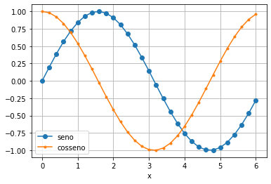

```python
import matplotlib.pyplot as plt
from numpy import arange,sin,cos
x = arange(0.0,6.2,0.2)
plt.plot(x,sin(x),'o-',x,cos(x),'.-') # Plota o gráfico com linhas e marcadores específicos
plt.xlabel('x') # Adiciona um "label" ao eixo x
plt.legend(('seno','cosseno'),loc = 0) # Adiciona legenda na localização 0
plt.grid(True) # Acrescente a grade (grid)
plt.savefig('testplot.png',format='png') # Salva o gráfico em formato png

plt.show() # Mostra o gráfico na tela
```

Na tabela a seguir, há alguns exemplos de linhas e marcadores:

- ’-’ Linha sólida
- ’--’ Linha tracejada
- ’-.’ Linha traço ponto
- ’:’ Linha pontilhada
- ’o’ Marcador circular
- ’ˆ’ Marcador triangular
- ’s’ Marcador quadrado
- ’h’ Marcador hexagonal
- ’x’ Marcador em x

E de localização das legendas:

- 0 ”Melhor” localização
- 1 Superior direita
- 2 Superior esquerda
- 3 Inferior esquerda
- 4 Inferior direita

Podemos ainda plotar mais de um gráfico na mesma figura:

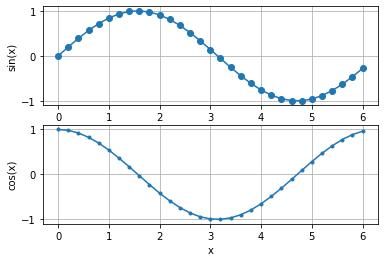

```python
import matplotlib.pyplot as plt
from numpy import arange,sin,cos
x = arange(0.0,6.2,0.2)
plt.subplot(2,1,1)
plt.plot(x,sin(x),'o-')
plt.xlabel('x');plt.ylabel('sin(x)')
plt.grid(True)
plt.subplot(2,1,2)
plt.plot(x,cos(x),'.-')
plt.xlabel('x');plt.ylabel('cos(x)')
plt.grid(True)
plt.show()
```

## Referências

Kiusalaas, J. (2013). **Numerical Methods in Engineering With Python 3**. Cambridge: Cambridge.  
Brasil, R.M.L.R.F, Balthazar, J.M., Góis, W. (2015) **Métodos Numéricos e Computacionais na Prática de Engenharias e Ciências**, São Paulo: Edgar Blucher